# Assess survival in imaging clusters

Ryan Corbett

2024

This script models event-free survival by imaging cluster

Load libraries and set directories

```r
library(tidyverse)
library(readxl)
library(survival)
library(patchwork)
```

```r
root_dir <- rprojroot::find_root(rprojroot::has_dir(".git"))

data_dir <- file.path(root_dir, "data")
analysis_dir <- file.path(root_dir, "analyses", "braf-fusions")
results_dir <- file.path(analysis_dir, "results")
input_dir <- file.path(analysis_dir, "input")
plot_dir <- file.path(analysis_dir, "plots")

source(file.path(analysis_dir, "util", "survival_models_interaction.R"))
fusion_file <- file.path(results_dir, "braf-fusion-breakpoints-by-patient.tsv")
hist_file <- file.path(data_dir, "histologies.tsv")
cluster_file <- file.path(input_dir, "imaging_clustering_cohort.csv")
fusion_dgd_file <- file.path(data_dir, "fusion-dgd.tsv.gz")
```

```r
hist <- read_tsv(hist_file, guess_max = 100000)
image_clusters <- read_csv(cluster_file) %>%
  dplyr::rename(cohort_participant_id = SubjectID,
                imaging_cluster = `Imaging Cluster Assignment`) %>%
  dplyr::mutate(imaging_cluster = glue::glue("cluster{imaging_cluster}")) %>%
  left_join(hist[,c("broad_histology", "cancer_group", "molecular_subtype", "cohort_participant_id", "Kids_First_Participant_ID")]) %>%
  dplyr::filter(!is.na(broad_histology) | !is.na(cancer_group) | !is.na(molecular_subtype)) %>%
  dplyr::distinct(cohort_participant_id, .keep_all = T) %>%
  dplyr::rename(OS_days = overall_survival_y,
                EFS_days = event_free_survival_y) %>%
  dplyr::mutate(OS_years = OS_days / 365.25,
                EFS_years = EFS_days / 365.25) %>%
  dplyr::mutate(EFS_status = case_when(
    `progressed?` == "y" ~ "EVENT",
    TRUE ~ "NO EVENT"
  )) %>%
  dplyr::mutate(imaging_cluster = factor(imaging_cluster)) %>%
  dplyr::mutate(extent_of_tumor_resection_x = case_when(
    extent_of_tumor_resection_x == "Not Applicable" ~ "No Resection",
    TRUE ~ extent_of_tumor_resection_x
  ))
fusions <- read_tsv(fusion_file)
image_clusters <- image_clusters %>%
  left_join(fusions)
```

Consolidate molecular subtypes into 6 groups (BRAF V600E, BRAF fusions, NF1, MAPK, wt, other alteration)

```r
image_clusters <- image_clusters %>%
  dplyr::mutate(mol_sub_group = case_when(
    grepl("BRAF V600E", molecular_subtype) ~ "LGG/GNG BRAF V600E",
    grepl("-BRAF", molecular_subtype) | (!is.na(breakpoint_exons_common) & is.na(molecular_subtype)) ~ "LGG/GNG KIAA1549::BRAF",
    grepl("NF1", molecular_subtype) ~ "LGG/GNG, NF1",
    grepl("MAPK", molecular_subtype) ~ "LGG/GNG, other MAPK",
    grepl("wildtype", molecular_subtype) ~ "LGG/GNG, wildtype",
    grepl("LGG|GNG", molecular_subtype) & !grepl("To be classified", molecular_subtype) ~ "LGG/GNG, other alteration",
    TRUE ~ NA_character_
  )) %>%
  dplyr::mutate(mol_sub_group = fct_relevel(mol_sub_group,
                c("LGG/GNG, wildtype", "LGG/GNG KIAA1549::BRAF",
                  "LGG/GNG BRAF V600E", "LGG/GNG, NF1",
                  "LGG/GNG, other MAPK", "LGG/GNG, other alteration")
  )) %>%
  dplyr::mutate(breakpoint_group = case_when(
    breakpoint_group == "15:9" ~ "15:09",
    breakpoint_group == "16:9" ~ "16:09",
    TRUE ~ breakpoint_group
  )) %>%
  write_tsv(file.path(results_dir, "imaging-clustering-cohort-subtype-survival.tsv"))
```

Frequency of molecular subtypes in imaging clusters

```r
round(table(image_clusters$mol_sub_group, image_clusters$imaging_cluster)/as.vector(table(image_clusters$mol_sub_group)), 2)
```

```
##
##                             cluster1 cluster2 cluster3
##   LGG/GNG, wildtype             0.20     0.20     0.60
##   LGG/GNG KIAA1549::BRAF        0.59     0.14     0.27
##   LGG/GNG BRAF V600E            0.18     0.27     0.55
##   LGG/GNG, NF1                  0.14     0.43     0.43
##   LGG/GNG, other MAPK           0.17     0.33     0.50
##   LGG/GNG, other alteration     0.33     0.50     0.17
```

```r
fisher.test(table(image_clusters$mol_sub_group, as.character(image_clusters$imaging_cluster)), simulate.p.value = T)
```

```
##
##  Fisher's Exact Test for Count Data with simulated p-value (based on
##  2000 replicates)
##
## data:  table(image_clusters$mol_sub_group, as.character(image_clusters$imaging_cluster))
## p-value = 0.0004998
## alternative hypothesis: two.sided
```

```r
round(table(image_clusters$imaging_cluster, image_clusters$extent_of_tumor_resection_x)/as.vector(table(image_clusters$imaging_cluster)), 2)
```

```
##
##            Biopsy only Gross/Near total resection No Resection
##   cluster1        0.04                       0.68         0.00
##   cluster2        0.12                       0.60         0.10
##   cluster3        0.14                       0.41         0.05
##
##            Partial resection
##   cluster1              0.28
##   cluster2              0.17
##   cluster3              0.41
```

```r
fisher.test(table(image_clusters$imaging_cluster, as.character(image_clusters$extent_of_tumor_resection_x)))
```

```
##
##  Fisher's Exact Test for Count Data
##
## data:  table(image_clusters$imaging_cluster, as.character(image_clusters$extent_of_tumor_resection_x))
## p-value = 0.001339
## alternative hypothesis: two.sided
```

Plot KM survival by imaging cluster

```r
kap_efs_cluster <- survival_analysis(
  metadata  = image_clusters,
  ind_var = "imaging_cluster",
  test = "kap.meier",
  metadata_sample_col = "cohort_participant_id",
  days_col = "EFS_days",
  status_col = "EFS_status"
  )
```

```
## Testing model: survival::Surv(EFS_days, EFS_status) ~ imaging_cluster with kap.meier
```

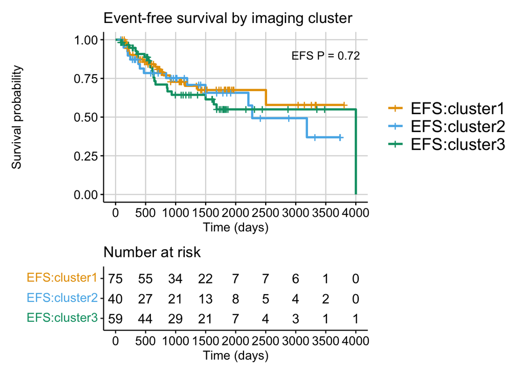

```r
km_plot_cluster <- plotKM(model = kap_efs_cluster,
                    variable = "imaging_cluster",
                    combined = F,
                    title = "Event-free survival by imaging cluster")

km_plot_cluster
```

```r
ggsave(file.path(plot_dir, "km_efs_imaging_cluster.pdf"),
       width = 7.5, height = 5)
```

Generate coxph interaction model including extent of tumor resection, molecualr subgroup, and imaging cluster

```r
efs_model_all_int <- fit_save_model(image_clusters,
                                    terms = "extent_of_tumor_resection_x+mol_sub_group*imaging_cluster",
               file.path(results_dir, "coxph_imaging_efs_int_resection_subtype_cluster.RDS"),
               "multivariate",
               years_col = "EFS_years", status_col = "EFS_status"
              )
car::Anova(readRDS(file.path(results_dir, "coxph_imaging_efs_int_resection_subtype_cluster.RDS")), type = 3, test = "Wald")
```

```
## Analysis of Deviance Table (Type III tests)
##
## Response: survival::Surv(time = EFS_years, event = EFS_status)
##                               Df   Chisq Pr(>Chisq)
## extent_of_tumor_resection_x    3 36.9027  4.825e-08 ***
## mol_sub_group                  5 10.8245   0.054972 .
## imaging_cluster                2  9.7668   0.007571 **
## mol_sub_group:imaging_cluster 10 17.8603   0.057366 .
## ---
## Signif. codes:  0 '***' 0.001 '**' 0.01 '*' 0.05 '.' 0.1 ' ' 1
```

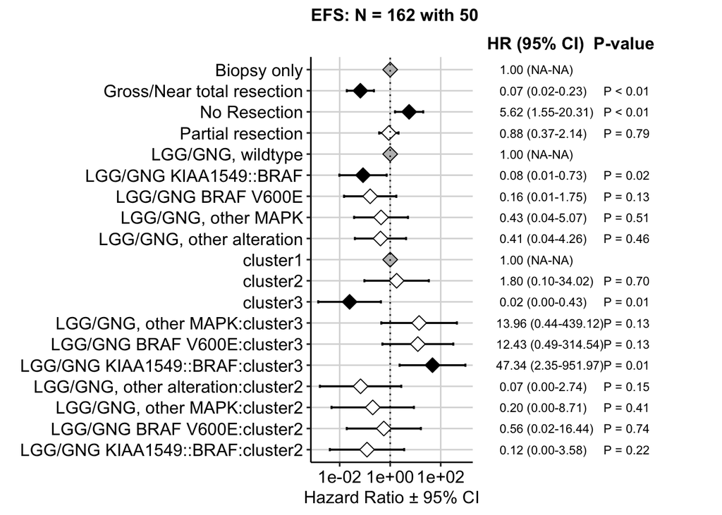

```r
plotForest(readRDS(file.path(results_dir, "coxph_imaging_efs_int_resection_subtype_cluster.RDS")))
```

```r
ggsave(file.path(plot_dir, "imaging_forest_efs_int_resection_subtype_cluster.pdf"),
       width = 9, height = 6)
```

There is some evidence for sig interaction effect between molecular subtype and imaging cluster, particularly in KIAA1549-BRAF fusion subtype tumors vs. wt. Determine if this interaction effect is significant when grouping tumors into BRAF fusions vs. non-BRAF fusion:

```r
image_clusters <- image_clusters %>%
  dplyr::mutate(braf_fusion = case_when(
    mol_sub_group == "LGG/GNG KIAA1549::BRAF" ~ "BRAF fusion",
    TRUE ~ "non-BRAF fusion"
  )) %>%
  dplyr::mutate(braf_fusion = fct_relevel(braf_fusion,
                                          c("non-BRAF fusion",
                                            "BRAF fusion")))

efs_model_fusion_int <- fit_save_model(image_clusters,
                                    terms = "extent_of_tumor_resection_x+braf_fusion*imaging_cluster",
               file.path(results_dir, "coxph_imaging_efs_int_resection_fusion_cluster.RDS"),
               "multivariate",
               years_col = "EFS_years", status_col = "EFS_status"
              )

car::Anova(readRDS(file.path(results_dir, "coxph_imaging_efs_int_resection_fusion_cluster.RDS")), type = 3, test = "Wald")
```

```
## Analysis of Deviance Table (Type III tests)
##
## Response: survival::Surv(time = EFS_years, event = EFS_status)
##                             Df   Chisq Pr(>Chisq)
## extent_of_tumor_resection_x  3 45.5280  7.146e-10 ***
## braf_fusion                  1  5.8541   0.015541 *
## imaging_cluster              2 10.0819   0.006468 **
## braf_fusion:imaging_cluster  2  8.4172   0.014868 *
## ---
## Signif. codes:  0 '***' 0.001 '**' 0.01 '*' 0.05 '.' 0.1 ' ' 1
```

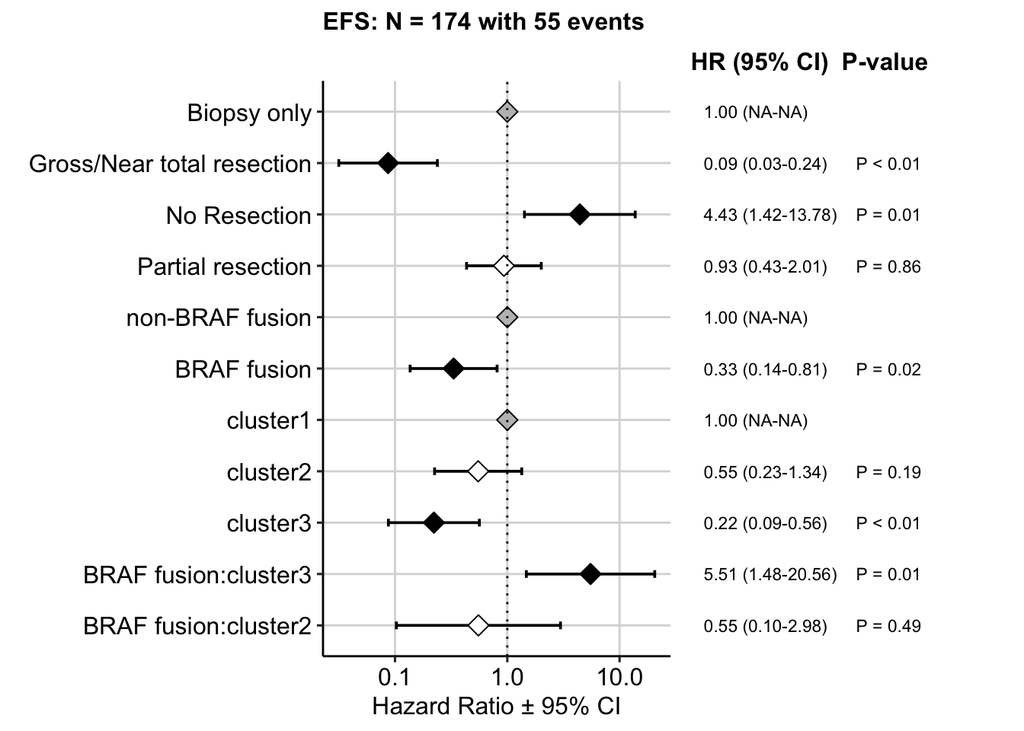

```r
plotForest(readRDS(file.path(results_dir, "coxph_imaging_efs_int_resection_fusion_cluster.RDS")))
```

```r
ggsave(file.path(plot_dir, "imaging_forest_efs_int_resection_fusion_cluster.pdf"),
       width = 7.5, height = 5)
```

BRAF fusion-imaging cluster interaction effect is now statistically signfiicant. Let’s model and plot survival by imaging cluster for BRAF fusion and non-BRAF fusion tumors

BRAF fusion tumors:

```r
kap_efs_braf_cluster <- survival_analysis(
  metadata  = image_clusters[grepl("LGG/GNG KIAA1549::BRAF", image_clusters$mol_sub_group),],
  ind_var = "imaging_cluster",
  test = "kap.meier",
  metadata_sample_col = "cohort_participant_id",
  days_col = "EFS_days",
  status_col = "EFS_status"
  )
```

```
## Testing model: survival::Surv(EFS_days, EFS_status) ~ imaging_cluster with kap.meier
```

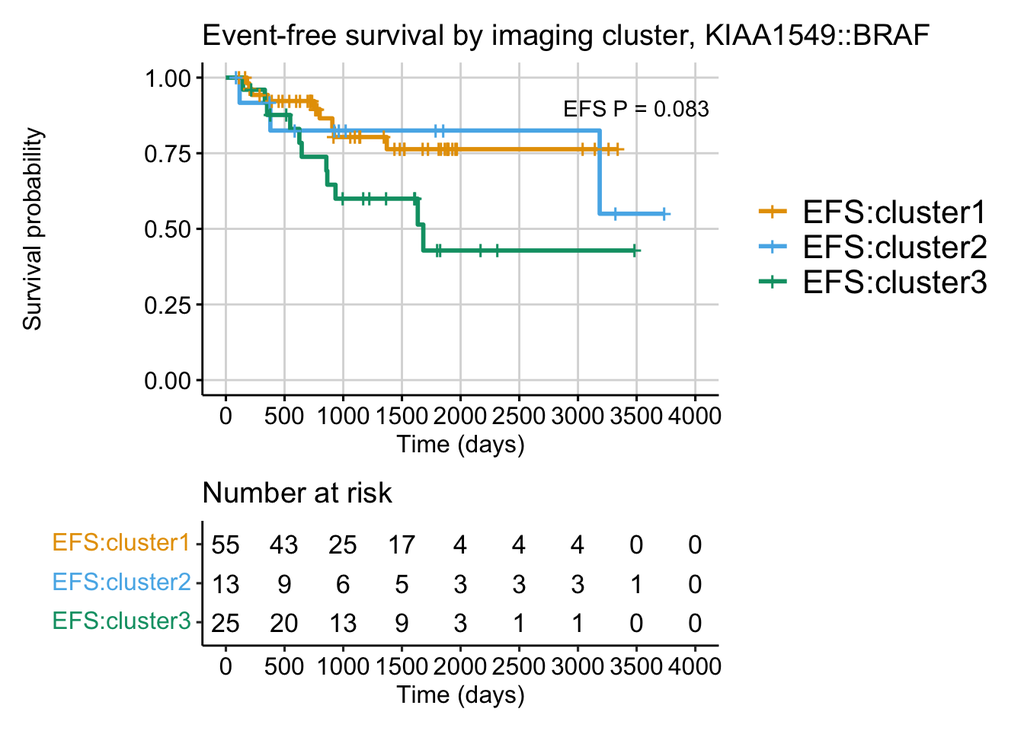

```r
km_plot_braf_cluster <- plotKM(model = kap_efs_braf_cluster,
                    variable = "imaging_cluster",
                    combined = F,
                    title = "Event-free survival by imaging cluster, KIAA1549::BRAF")

km_plot_braf_cluster
```

```r
ggsave(file.path(plot_dir, "km_efs_imaging_braf_cluster.pdf"),
       width = 7.5, height = 5)
```

```r
efs_model_braf_cluster_add <- fit_save_model(image_clusters[grepl("KIAA1549::BRAF", image_clusters$mol_sub_group),],
                                    terms = "extent_of_tumor_resection_x+imaging_cluster",
               file.path(results_dir, "coxph_imaging_braf_efs_add_resection_cluster.RDS"),
               "multivariate",
               years_col = "EFS_years", status_col = "EFS_status"
              )

anova(readRDS(file.path(results_dir, "coxph_imaging_braf_efs_add_resection_cluster.RDS")))
```

```
## Analysis of Deviance Table
##  Cox model: response is survival::Surv(time = EFS_years, event = EFS_status)
## Terms added sequentially (first to last)
##
##                              loglik  Chisq Df Pr(>|Chi|)
## NULL                        -91.898
## extent_of_tumor_resection_x -79.038 25.721  3  1.091e-05 ***
## imaging_cluster             -78.130  1.815  2     0.4035
## ---
## Signif. codes:  0 '***' 0.001 '**' 0.01 '*' 0.05 '.' 0.1 ' ' 1
```

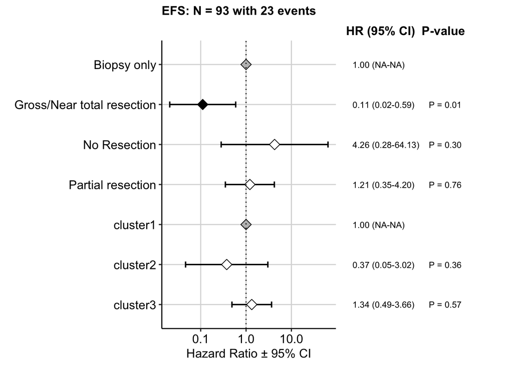

```r
plotForest(readRDS(file.path(results_dir, "coxph_imaging_braf_efs_add_resection_cluster.RDS")))
```

```r
ggsave(file.path(plot_dir, "imaging_forest_efs_braf_add_resection_cluster.pdf"),
       width = 7.5, height = 3)
```

Non-BRAF fusion tumors:

```r
kap_efs_nonbraf_cluster <- survival_analysis(
  metadata  = image_clusters[!grepl("LGG/GNG KIAA1549::BRAF", image_clusters$mol_sub_group),],
  ind_var = "imaging_cluster",
  test = "kap.meier",
  metadata_sample_col = "cohort_participant_id",
  days_col = "EFS_days",
  status_col = "EFS_status"
  )
```

```
## Testing model: survival::Surv(EFS_days, EFS_status) ~ imaging_cluster with kap.meier
```

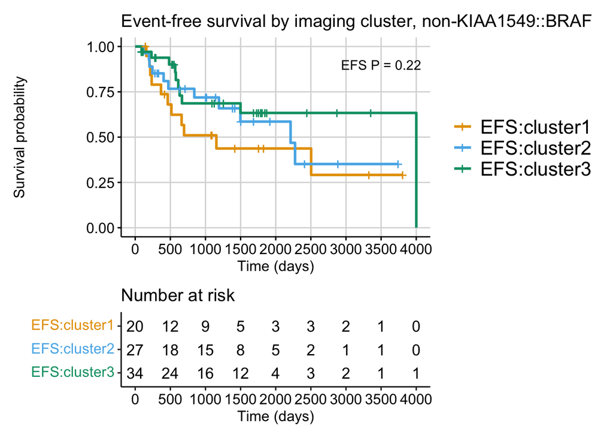

```r
km_plot_nonbraf_cluster <- plotKM(model = kap_efs_nonbraf_cluster,
                    variable = "imaging_cluster",
                    combined = F,
                    title = "Event-free survival by imaging cluster, non-KIAA1549::BRAF")

km_plot_nonbraf_cluster
```

```r
ggsave(file.path(plot_dir, "km_efs_imaging_nonbraf_cluster.pdf"),
       width = 7.5, height = 5)
```

```r
efs_model_nonbraf_cluster_add <- fit_save_model(image_clusters[!grepl("KIAA1549::BRAF", image_clusters$mol_sub_group),],
                                    terms = "extent_of_tumor_resection_x+imaging_cluster",
               file.path(results_dir, "coxph_imaging_nonbraf_efs_add_resection_cluster.RDS"),
               "multivariate",
               years_col = "EFS_years", status_col = "EFS_status"
              )

anova(readRDS(file.path(results_dir, "coxph_imaging_nonbraf_efs_add_resection_cluster.RDS")))
```

```
## Analysis of Deviance Table
##  Cox model: response is survival::Surv(time = EFS_years, event = EFS_status)
## Terms added sequentially (first to last)
##
##                               loglik   Chisq Df Pr(>|Chi|)
## NULL                        -118.198
## extent_of_tumor_resection_x -102.204 31.9870  3  5.267e-07 ***
## imaging_cluster              -97.204  9.9995  2   0.006739 **
## ---
## Signif. codes:  0 '***' 0.001 '**' 0.01 '*' 0.05 '.' 0.1 ' ' 1
```

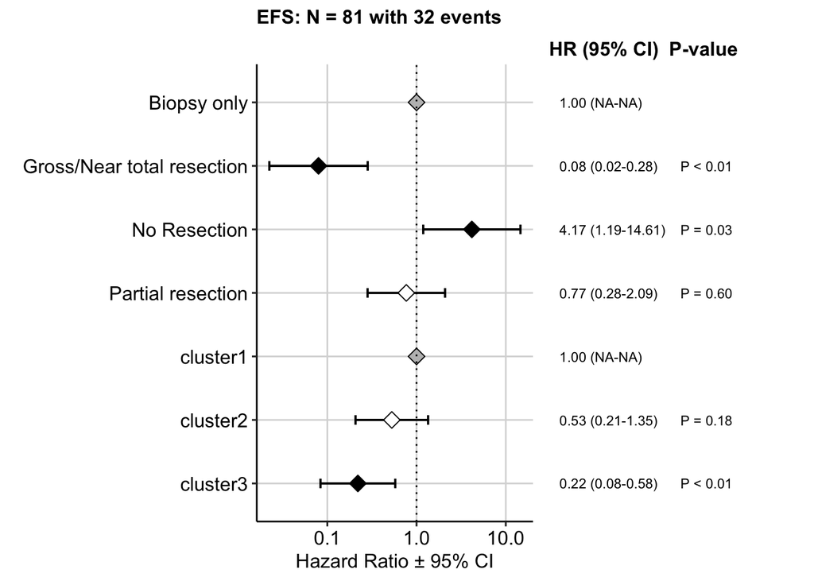

```r
plotForest(readRDS(file.path(results_dir, "coxph_imaging_nonbraf_efs_add_resection_cluster.RDS")))
```

```r
ggsave(file.path(plot_dir, "imaging_forest_efs_nonbraf_add_resection_cluster.pdf"),
       width = 7.5, height = 3)
```

Plot BRAF fusion EFS by breakpoint type (common vs. rare)

```r
kap_efs_type <- survival_analysis(
  metadata  = image_clusters[grepl("LGG/GNG KIAA1549::BRAF", image_clusters$mol_sub_group),],
  ind_var = "breakpoint_type",
  test = "kap.meier",
  metadata_sample_col = "cohort_participant_id",
  days_col = "EFS_days",
  status_col = "EFS_status"
  )
```

```
## Testing model: survival::Surv(EFS_days, EFS_status) ~ breakpoint_type with kap.meier
```

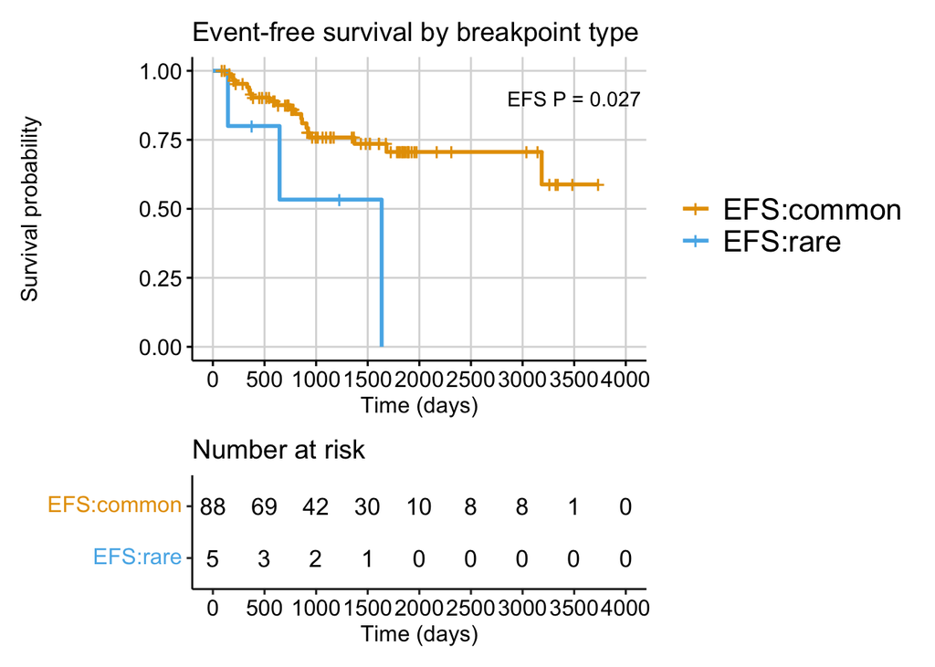

```r
km_plot_type <- plotKM(model = kap_efs_type,
                    variable = "breakpoint_type",
                    combined = F,
                    title = "Event-free survival by breakpoint type")

km_plot_type
```

```r
ggsave(file.path(plot_dir, "km_efs_imaging_braf_breakpoint_type.pdf"),
       width = 7.5, height = 5)
```

```r
kap_efs_group <- survival_analysis(
  metadata  = image_clusters[grepl("LGG/GNG KIAA1549::BRAF", image_clusters$mol_sub_group),],
  ind_var = "breakpoint_group",
  test = "kap.meier",
  metadata_sample_col = "cohort_participant_id",
  days_col = "EFS_days",
  status_col = "EFS_status"
  )
```

```
## Testing model: survival::Surv(EFS_days, EFS_status) ~ breakpoint_group with kap.meier
```

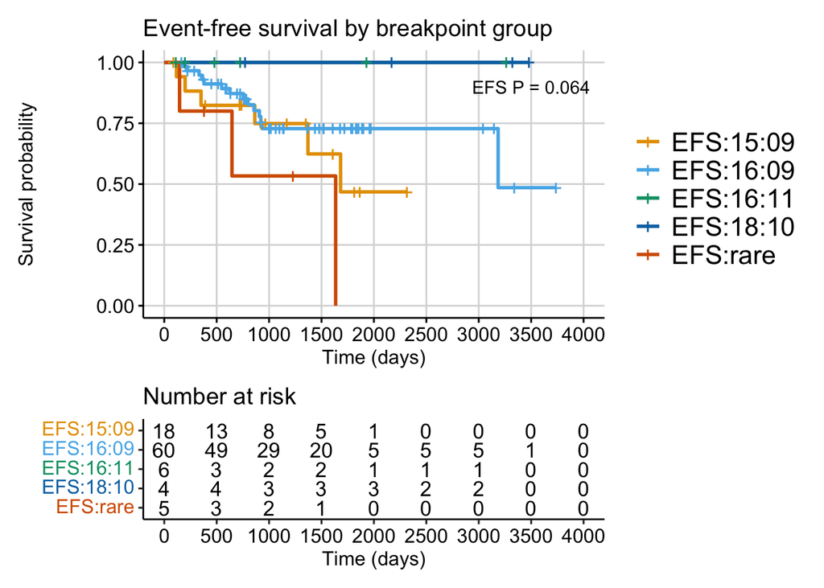

```r
km_plot_group <- plotKM(model = kap_efs_group,
                    variable = "breakpoint_group",
                    combined = F,
                    title = "Event-free survival by breakpoint group")

km_plot_group
```

```r
ggsave(file.path(plot_dir, "km_efs_imaging_braf_breakpoint_group.pdf"),
       width = 7.5, height = 5)
```

```r
efs_model_braf_cluster_breakpoint_add <- fit_save_model(image_clusters[grepl("KIAA1549::BRAF", image_clusters$mol_sub_group),],
                                    terms = "extent_of_tumor_resection_x+imaging_cluster+breakpoint_type",
               file.path(results_dir, "coxph_imaging_nonbraf_efs_add_resection_cluster_breakpoint_type.RDS"),
               "multivariate",
               years_col = "EFS_years", status_col = "EFS_status"
              )

anova(readRDS(file.path(results_dir, "coxph_imaging_nonbraf_efs_add_resection_cluster_breakpoint_type.RDS")))
```

```
## Analysis of Deviance Table
##  Cox model: response is survival::Surv(time = EFS_years, event = EFS_status)
## Terms added sequentially (first to last)
##
##                              loglik   Chisq Df Pr(>|Chi|)
## NULL                        -91.898
## extent_of_tumor_resection_x -79.038 25.7208  3  1.091e-05 ***
## imaging_cluster             -78.130  1.8150  2     0.4035
## breakpoint_type             -77.889  0.4836  1     0.4868
## ---
## Signif. codes:  0 '***' 0.001 '**' 0.01 '*' 0.05 '.' 0.1 ' ' 1
```

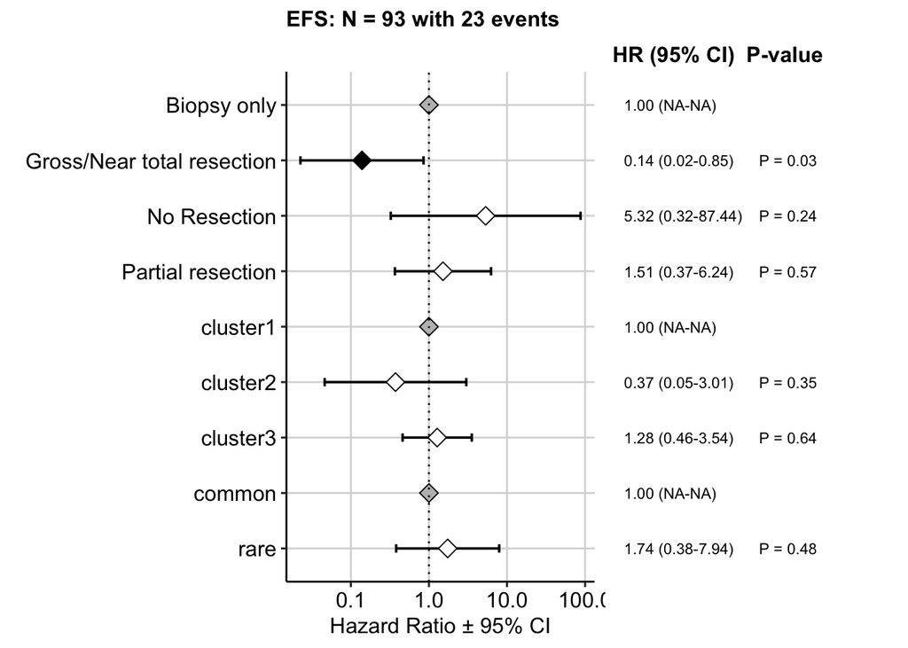

```r
plotForest(readRDS(file.path(results_dir, "coxph_imaging_nonbraf_efs_add_resection_cluster_breakpoint_type.RDS")))
```

```r
ggsave(file.path(plot_dir, "imaging_forest_efs_braf_add_resection_cluster_type.pdf"),
       width = 7.5, height = 3)
```

```r
braf_model_efs <- fit_save_model(image_clusters[grepl("KIAA1549::BRAF", image_clusters$mol_sub_group),],
                                    terms = "extent_of_tumor_resection_x+imaging_cluster+breakpoint_group",
               file.path(results_dir, "coxph_imaging_nonbraf_efs_add_resection_cluster_breakpoint_group.RDS"),
               "multivariate",
               years_col = "EFS_years", status_col = "EFS_status"
              )
anova(readRDS(file.path(results_dir, "coxph_imaging_nonbraf_efs_add_resection_cluster_breakpoint_group.RDS")))
```

```
## Analysis of Deviance Table
##  Cox model: response is survival::Surv(time = EFS_years, event = EFS_status)
## Terms added sequentially (first to last)
##
##                              loglik   Chisq Df Pr(>|Chi|)
## NULL                        -91.898
## extent_of_tumor_resection_x -79.038 25.7208  3  1.091e-05 ***
## imaging_cluster             -78.130  1.8150  2    0.40353
## breakpoint_group            -73.415  9.4309  4    0.05119 .
## ---
## Signif. codes:  0 '***' 0.001 '**' 0.01 '*' 0.05 '.' 0.1 ' ' 1
```

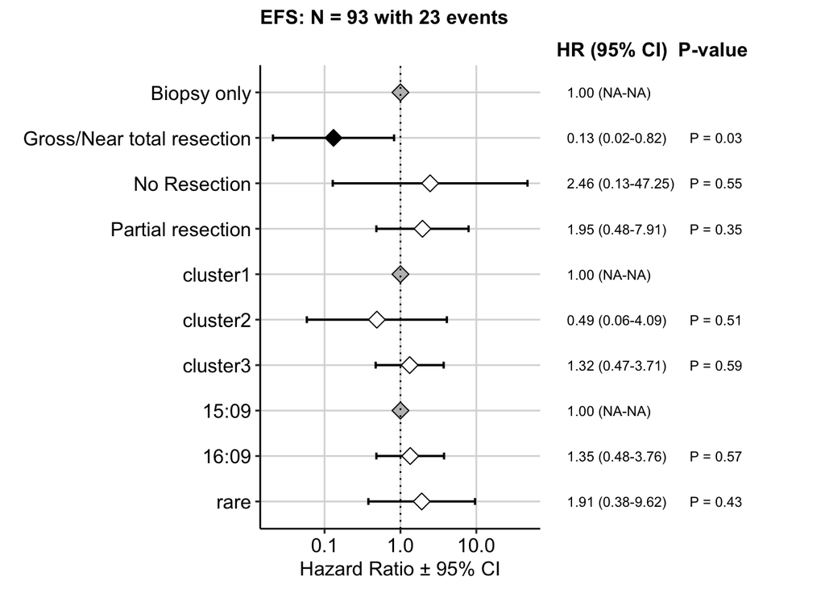

```r
plotForest(readRDS(file.path(results_dir, "coxph_imaging_nonbraf_efs_add_resection_cluster_breakpoint_group.RDS")))
```

```r
ggsave(file.path(plot_dir, "imaging_forest_efs_braf_add_resection_cluster_group.pdf"),
       width = 7.5, height = 3)
```

Plot survival by molecular subtype

```r
kap_efs_subtype <- survival_analysis(
  metadata  = image_clusters,
  ind_var = "mol_sub_group",
  test = "kap.meier",
  metadata_sample_col = "cohort_participant_id",
  days_col = "EFS_days",
  status_col = "EFS_status"
  )
```

```
## Testing model: survival::Surv(EFS_days, EFS_status) ~ mol_sub_group with kap.meier
```

[figure not shown]

```r
km_plot_subtype <- plotKM(model = kap_efs_subtype,
                    variable = "mol_sub_group",
                    combined = F,
                    title = "Event-free survival by molecular subtype")

km_plot_subtype
```

```r
ggsave(file.path(plot_dir, "km_efs_imaging_braf_molecular_subtype.pdf"),
       width = 11, height = 5)
```